# Homework1_OptionB

Nicole Phelan

2025-10-05

Load libraries for plotting

```r
library(ggplot2)
library(ggpubr)
```

Estimate the PCA for each of the K values

```r
# K=2
COV_K2 <- as.matrix(read.table("allRS_poly_K2.cov"))
PCA_K2 <- eigen(COV_K2)

# K=3
COV_K3 <- as.matrix(read.table("allRS_poly_K3.cov"))
PCA_K3 <- eigen(COV_K3)

# K=4
COV_K4 <- as.matrix(read.table("allRS_poly_K4.cov"))
PCA_K4 <- eigen(COV_K4)

# K=5
COV_K5 <- as.matrix(read.table("allRS_poly_K5.cov"))
PCA_K5 <- eigen(COV_K5)
```

How much variance do the first 3 eigenvalues/PC axes explain?

```r
#K=2
var_K2 <- round(PCA_K2$values/sum(PCA_K2$values),3)
print(c("The first 4 eigenvalues for K=2 explain the following variance:",var_K2[1:4]))
```

```
## [1] "The first 4 eigenvalues for K=2 explain the following variance:"
## [2] "0.057"
## [3] "0.016"
## [4] "0.015"
## [5] "0.014"
```

```r
#K=3
var_K3 <- round(PCA_K3$values/sum(PCA_K3$values),3)
print(c("The first 4 eigenvalues for K=3 explain the following variance:",var_K3[1:4]))
```

```
## [1] "The first 4 eigenvalues for K=3 explain the following variance:"
## [2] "0.057"
## [3] "0.037"
## [4] "0.014"
## [5] "0.013"
```

```r
#K=4
var_K4 <- round(PCA_K4$values/sum(PCA_K4$values),3)
print(c("The first 4 eigenvalues for K=4 explain the following variance:",var_K4[1:4]))
```

```
## [1] "The first 4 eigenvalues for K=4 explain the following variance:"
## [2] "0.056"
## [3] "0.036"
## [4] "0.029"
## [5] "0.013"
```

```r
#K=5
var_K5 <- round(PCA_K5$values/sum(PCA_K5$values),3)
print(c("The first 4 eigenvalues for K=5 explain the following variance:",var_K5[1:4]))
```

```
## [1] "The first 4 eigenvalues for K=5 explain the following variance:"
## [2] "0.055"
## [3] "0.036"
## [4] "0.029"
## [5] "0.028"
```

Screeplots for the variance explained for each K value

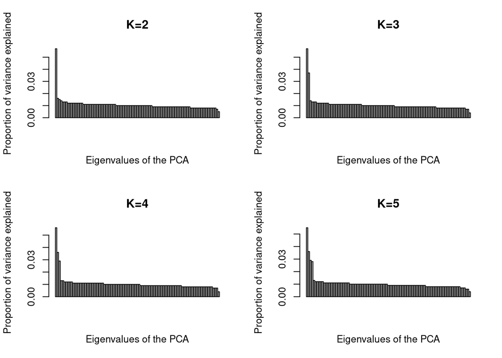

```r
par(mfrow=c(2,2))

#K=2
barplot(var_K2,
        xlab="Eigenvalues of the PCA",
        ylab="Proportion of variance explained",
        main="K=2")
#K=3
barplot(var_K3,
        xlab="Eigenvalues of the PCA",
        ylab="Proportion of variance explained",
        main="K=3")

#K=4
barplot(var_K4,
        xlab="Eigenvalues of the PCA",
        ylab="Proportion of variance explained",
        main="K=4")

#K=5
barplot(var_K5,
        xlab="Eigenvalues of the PCA",
        ylab="Proportion of variance explained",
        main="K=5")
```

As you can see from the first three eigenvalues and the screeplots, the drop in variance explained occurs rapidly between PC1 and PC2 when K=2, but it drops more gradually as K increases.

Data wrangling that takes in the names of my samples and makes them into a tidy format for plotting

```r
names <- read.table("allRS_bam.list")
names <- unlist(strsplit(basename(as.character(names[,1])), split = ".sorted.rmdup.bam"))
split = strsplit(names, "_")
pops <- data.frame(names[1:95], do.call(rbind, split[1:95]))
names(pops) = c("Ind", "Pop", "Row", "Col")

#K=2
data_K2=as.data.frame(PCA_K2$vectors)
data_K2=data_K2[,c(1:3)]
data_K2= cbind(data_K2, pops)

#K=3
data_K3=as.data.frame(PCA_K3$vectors)
data_K3=data_K3[,c(1:3)]
data_K3= cbind(data_K3, pops)

#K=4
data_K4=as.data.frame(PCA_K4$vectors)
data_K4=data_K4[,c(1:3)]
data_K4= cbind(data_K4, pops)

#K=5
data_K5=as.data.frame(PCA_K5$vectors)
data_K5=data_K5[,c(1:3)]
data_K5= cbind(data_K5, pops)
```

Plotting all of the PCAs in ggplot for the different K values for PC1 and PC2

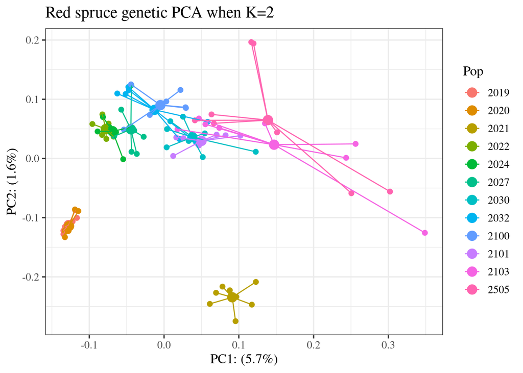

```r
#K=2
ggscatter(data_K2, x = "V1", y = "V2",
          color = "Pop",
          mean.point = TRUE,
          star.plot = TRUE,
          main="Red spruce genetic PCA when K=2") +
  theme_bw(base_size = 13, base_family = "Times") +
  labs(x = paste0("PC1: (",var_K2[1]*100,"%)"), y = paste0("PC2: (",var_K2[2]*100,"%)"))
```

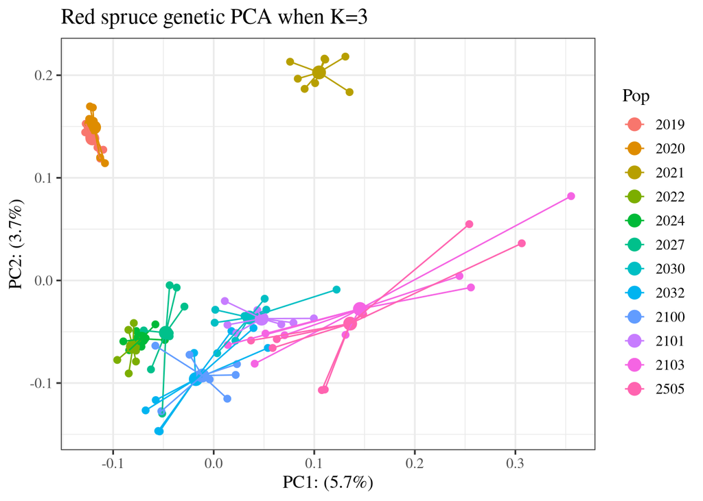

```r
#K=3
ggscatter(data_K3, x = "V1", y = "V2",
          color = "Pop",
          mean.point = TRUE,
          star.plot = TRUE,
          main="Red spruce genetic PCA when K=3") +
  theme_bw(base_size = 13, base_family = "Times") +
  labs(x = paste0("PC1: (",var_K3[1]*100,"%)"), y = paste0("PC2: (",var_K3[2]*100,"%)"))
```

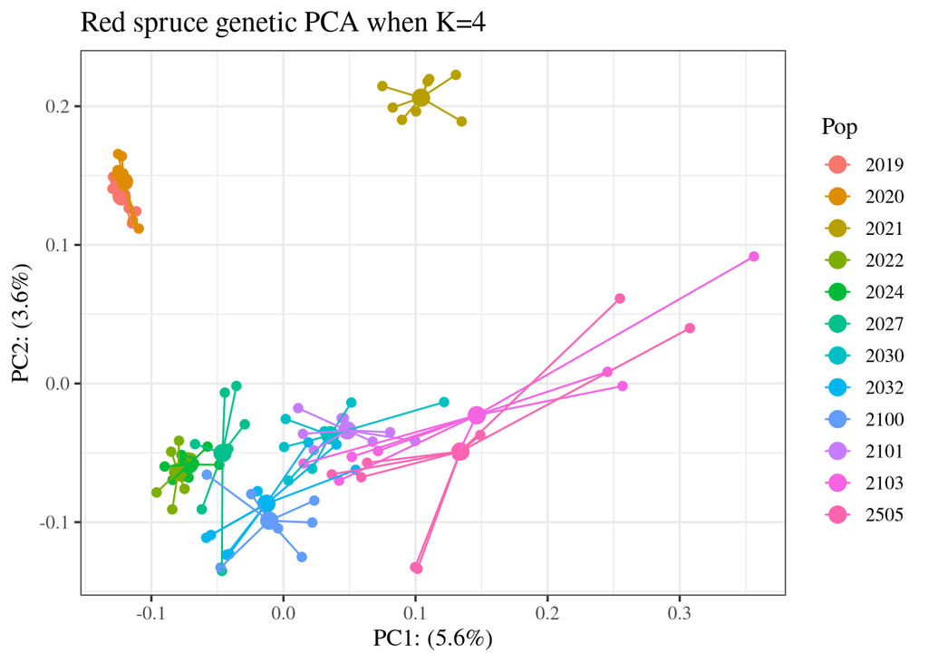

```r
#K=4
ggscatter(data_K4, x = "V1", y = "V2",
          color = "Pop",
          mean.point = TRUE,
          star.plot = TRUE,
          main="Red spruce genetic PCA when K=4") +
  theme_bw(base_size = 13, base_family = "Times") +
  labs(x = paste0("PC1: (",var_K4[1]*100,"%)"), y = paste0("PC2: (",var_K4[2]*100,"%)"))
```

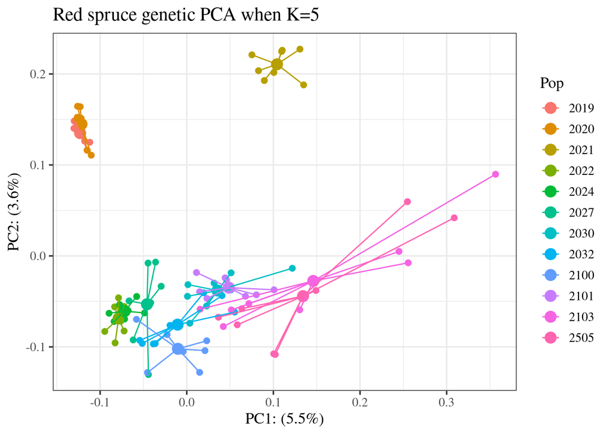

```r
#K=5
ggscatter(data_K5, x = "V1", y = "V2",
          color = "Pop",
          mean.point = TRUE,
          star.plot = TRUE,
          main="Red spruce genetic PCA when K=5") +
  theme_bw(base_size = 13, base_family = "Times") +
  labs(x = paste0("PC1: (",var_K5[1]*100,"%)"), y = paste0("PC2: (",var_K5[2]*100,"%)"))
```

Generally, all of the PCAs showed similar spreads of the variance, however the PCA for K=2 looked like a flipped version of the PCAs for K=3, K=4, and K=5.

Let’s try repeating the PCA but with the 3rd PC axis this time.

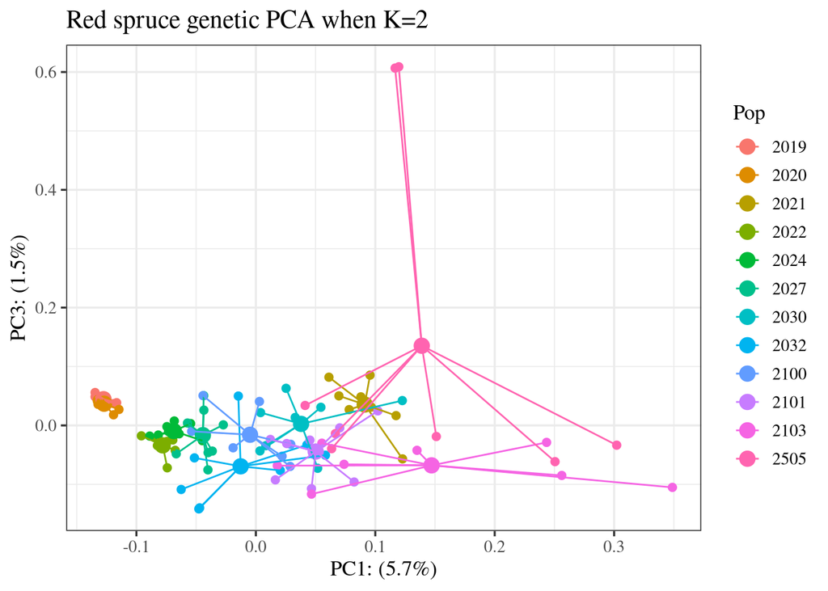

```r
#K=2
ggscatter(data_K2, x = "V1", y = "V3",
          color = "Pop",
          mean.point = TRUE,
          star.plot = TRUE,
          main="Red spruce genetic PCA when K=2") +
  theme_bw(base_size = 13, base_family = "Times") +
  labs(x = paste0("PC1: (",var_K2[1]*100,"%)"), y = paste0("PC3: (",var_K2[3]*100,"%)"))
```

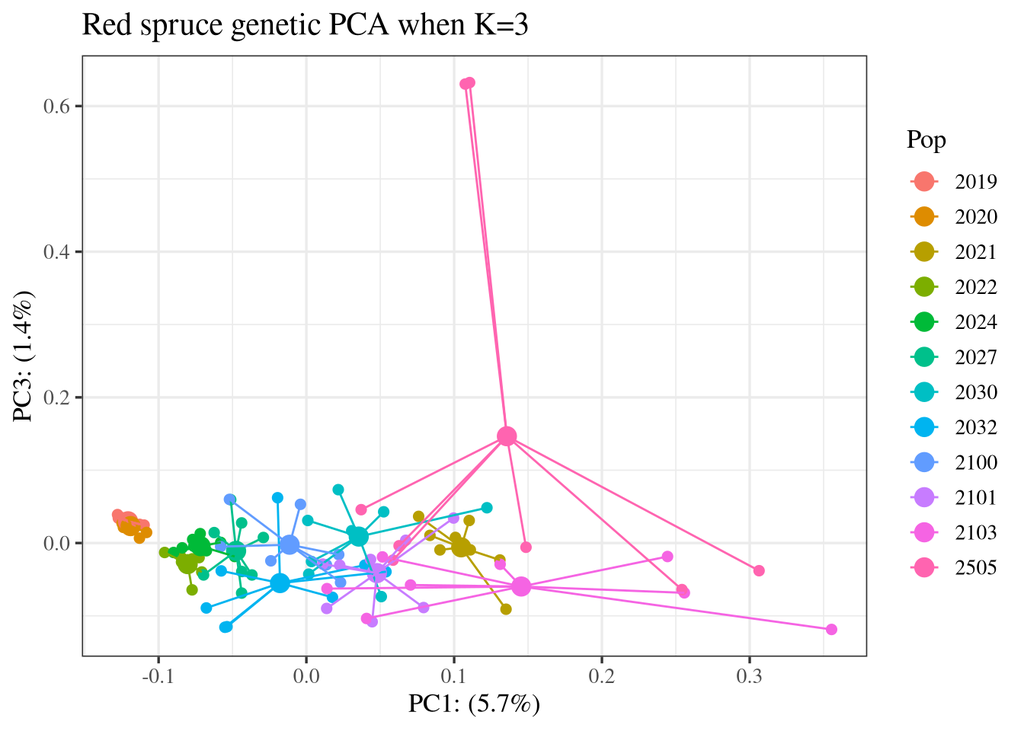

```r
#K=3
ggscatter(data_K3, x = "V1", y = "V3",
          color = "Pop",
          mean.point = TRUE,
          star.plot = TRUE,
          main="Red spruce genetic PCA when K=3") +
  theme_bw(base_size = 13, base_family = "Times") +
  labs(x = paste0("PC1: (",var_K3[1]*100,"%)"), y = paste0("PC3: (",var_K3[3]*100,"%)"))
```

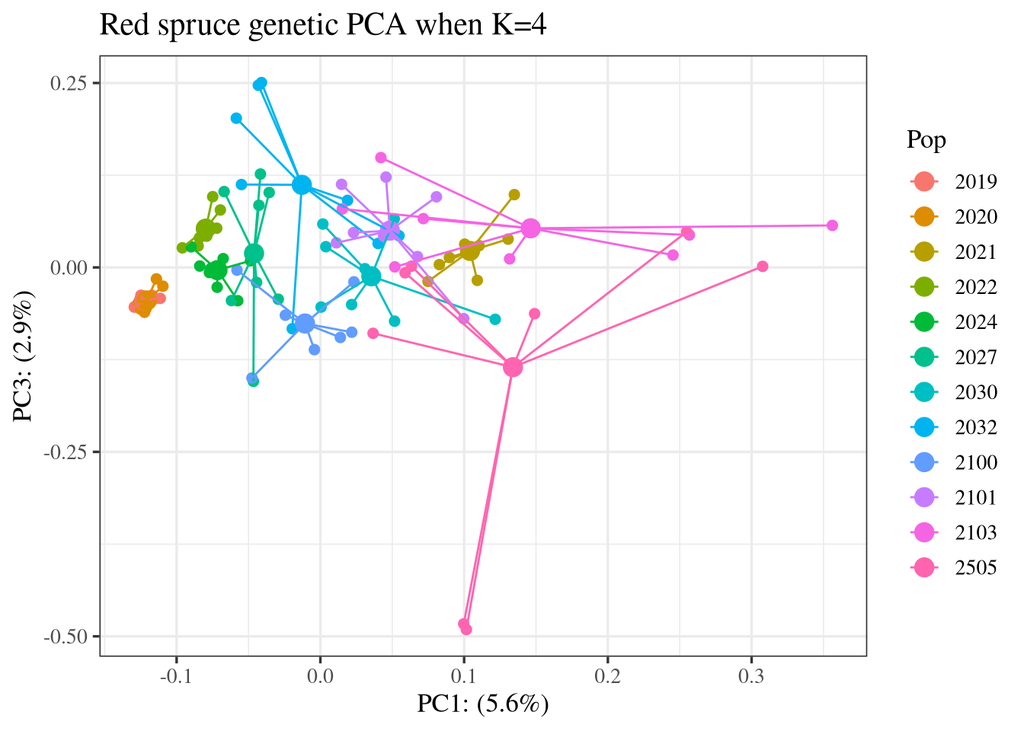

```r
#K=4
ggscatter(data_K4, x = "V1", y = "V3",
          color = "Pop",
          mean.point = TRUE,
          star.plot = TRUE,
          main="Red spruce genetic PCA when K=4") +
  theme_bw(base_size = 13, base_family = "Times") +
  labs(x = paste0("PC1: (",var_K4[1]*100,"%)"), y = paste0("PC3: (",var_K4[3]*100,"%)"))
```

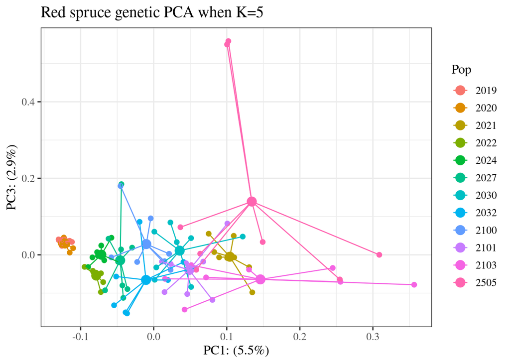

```r
#K=5
ggscatter(data_K5, x = "V1", y = "V3",
          color = "Pop",
          mean.point = TRUE,
          star.plot = TRUE,
          main="Red spruce genetic PCA when K=5") +
  theme_bw(base_size = 13, base_family = "Times") +
  labs(x = paste0("PC1: (",var_K5[1]*100,"%)"), y = paste0("PC3: (",var_K5[3]*100,"%)"))
```

This time, K=4 produces the PCA that looks like a flipped version of the rest of the PCAs.

Generating a figure for the write-up

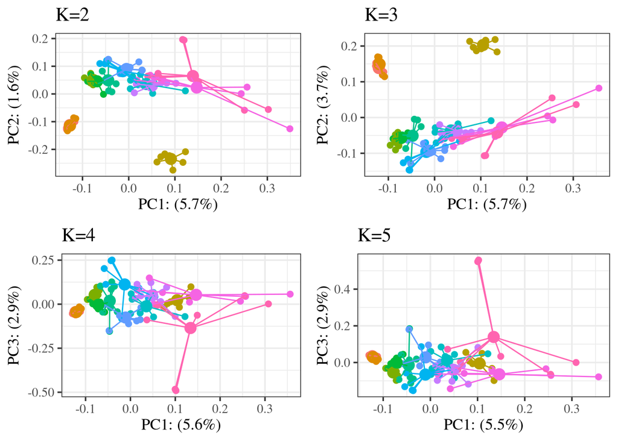

```r
#K=2
K2P1P2=ggscatter(data_K2, x = "V1", y = "V2",
          color = "Pop",
          mean.point = TRUE,
          star.plot = TRUE,
          main="K=2") +
  theme_bw(base_size = 13, base_family = "Times") +
  guides(color = "none") +
  labs(x = paste0("PC1: (",var_K2[1]*100,"%)"), y = paste0("PC2: (",var_K2[2]*100,"%)"))

#K=3
K3P1P2=ggscatter(data_K3, x = "V1", y = "V2",
          color = "Pop",
          mean.point = TRUE,
          star.plot = TRUE,
          main="K=3") +
  theme_bw(base_size = 13, base_family = "Times") +
  guides(color = "none") +
  labs(x = paste0("PC1: (",var_K3[1]*100,"%)"), y = paste0("PC2: (",var_K3[2]*100,"%)"))

#K=4
K4P1P2=ggscatter(data_K4, x = "V1", y = "V2",
          color = "Pop",
          mean.point = TRUE,
          star.plot = TRUE,
          main="Red spruce genetic PCA when K=4") +
  theme_bw(base_size = 13, base_family = "Times") +
  labs(x = paste0("PC1: (",var_K4[1]*100,"%)"), y = paste0("PC2: (",var_K4[2]*100,"%)"))

#K=5
K5P1P2=ggscatter(data_K5, x = "V1", y = "V2",
          color = "Pop",
          mean.point = TRUE,
          star.plot = TRUE,
          main="Red spruce genetic PCA when K=5") +
  theme_bw(base_size = 13, base_family = "Times") +
  labs(x = paste0("PC1: (",var_K5[1]*100,"%)"), y = paste0("PC2: (",var_K5[2]*100,"%)"))

#K=2
K2P1P3=ggscatter(data_K2, x = "V1", y = "V3",
          color = "Pop",
          mean.point = TRUE,
          star.plot = TRUE,
          main="Red spruce genetic PCA when K=2") +
  theme_bw(base_size = 13, base_family = "Times") +
  labs(x = paste0("PC1: (",var_K2[1]*100,"%)"), y = paste0("PC3: (",var_K2[3]*100,"%)"))

#K=3
K3P1P3=ggscatter(data_K3, x = "V1", y = "V3",
          color = "Pop",
          mean.point = TRUE,
          star.plot = TRUE,
          main="Red spruce genetic PCA when K=3") +
  theme_bw(base_size = 13, base_family = "Times") +
  labs(x = paste0("PC1: (",var_K3[1]*100,"%)"), y = paste0("PC3: (",var_K3[3]*100,"%)"))

#K=4
K4P1P3=ggscatter(data_K4, x = "V1", y = "V3",
          color = "Pop",
          mean.point = TRUE,
          star.plot = TRUE,
          main="K=4") +
  theme_bw(base_size = 13, base_family = "Times") +
  guides(color = "none") +
  labs(x = paste0("PC1: (",var_K4[1]*100,"%)"), y = paste0("PC3: (",var_K4[3]*100,"%)"))

#K=5
K5P1P3=ggscatter(data_K5, x = "V1", y = "V3",
          color = "Pop",
          mean.point = TRUE,
          star.plot = TRUE,
          main="K=5") +
  theme_bw(base_size = 13, base_family = "Times") +
  guides(color = "none") +
  labs(x = paste0("PC1: (",var_K5[1]*100,"%)"), y = paste0("PC3: (",var_K5[3]*100,"%)"))

ggarrange(K2P1P2, K3P1P2,
          #K4P1P2, K5P1P2, K2P1P3, K3P1P3,
          K4P1P3, K5P1P3, ncol = 2, nrow = 2)
```

Moving onto the admixture analysis, I will start by reading in all of the data.

```r
## rank order the samples according to population code
ord<-order(pops[,2])

#K=2
q_K2 <- read.table("allRS_poly_K2.admix.2.Q", sep=" ", header=F)
K_2=dim(q_K2)[2] #Find the level of K modeled

#K=3
q_K3 <- read.table("allRS_poly_K3.admix.3.Q", sep=" ", header=F)
K_3=dim(q_K3)[2] #Find the level of K modeled
## rank order the samples according to population code

#K=4
q_K4 <- read.table("allRS_poly_K4.admix.4.Q", sep=" ", header=F)
K_4=dim(q_K4)[2] #Find the level of K modeled
## rank order the samples according to population code

#K=5
q_K5 <- read.table("allRS_poly_K5.admix.5.Q", sep=" ", header=F)
K_5=dim(q_K5)[2] #Find the level of K modeled
## rank order the samples according to population code
```

Plotting the admixture proportions for all of the K values

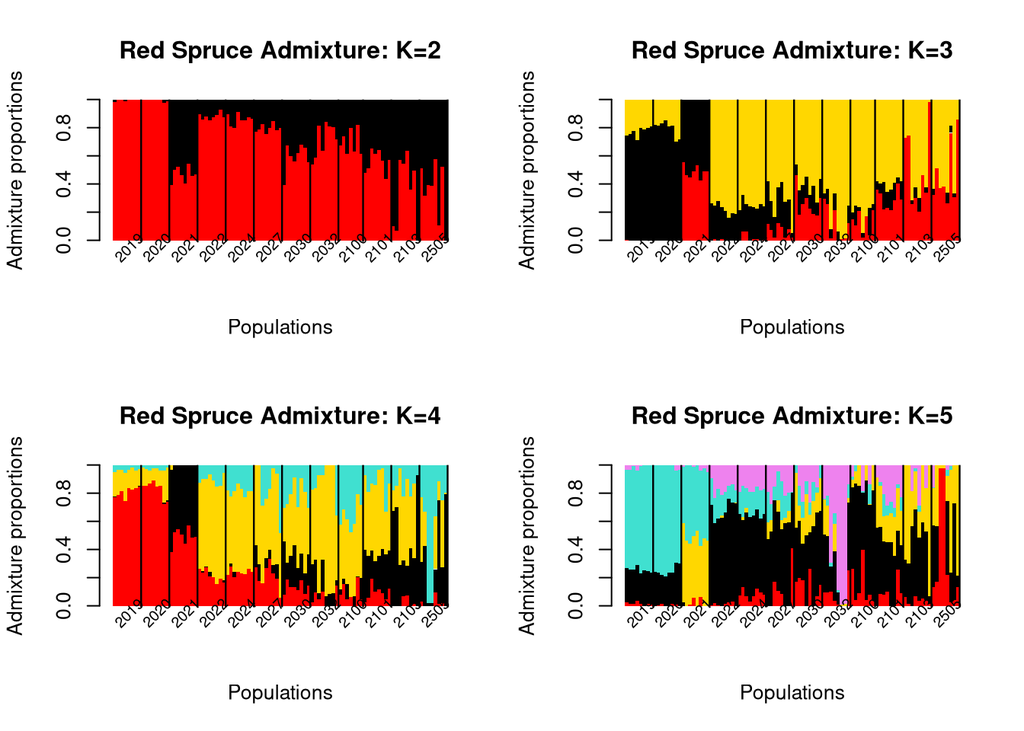

```r
par(mfrow=c(2,2))

#K=2
barplot(t(q_K2)[,ord],
        #col=cols[1:K],
        col=c("red","black"),
        space=0,border=NA,
        xlab="Populations",ylab="Admixture proportions",
        main=paste0("Red Spruce Admixture: K=",K_2))
text(tapply(1:nrow(pops),pops[ord,2],mean),-0.05,unique(pops[ord,2]),xpd=T,cex=0.75,srt=45)
abline(v=cumsum(sapply(unique(pops[ord,2]),function(x){sum(pops[ord,2]==x)})),col=1,lwd=1.2)

#K=3
barplot(t(q_K3)[,ord],
        #col=cols[1:K],
        col=c("red","black","gold"),
        space=0,border=NA,
        xlab="Populations",ylab="Admixture proportions",
        main=paste0("Red Spruce Admixture: K=",K_3))
text(tapply(1:nrow(pops),pops[ord,2],mean),-0.05,unique(pops[ord,2]),xpd=T,cex=0.75,srt=45)
abline(v=cumsum(sapply(unique(pops[ord,2]),function(x){sum(pops[ord,2]==x)})),col=1,lwd=1.2)

#K=4
barplot(t(q_K4)[,ord],
        #col=cols[1:K],
        col=c("red","black","gold","turquoise"),
        space=0,border=NA,
        xlab="Populations",ylab="Admixture proportions",
        main=paste0("Red Spruce Admixture: K=",K_4))
text(tapply(1:nrow(pops),pops[ord,2],mean),-0.05,unique(pops[ord,2]),xpd=T,cex=0.75,srt=45)
abline(v=cumsum(sapply(unique(pops[ord,2]),function(x){sum(pops[ord,2]==x)})),col=1,lwd=1.2)

#K=5
barplot(t(q_K5)[,ord],
        #col=cols[1:K],
        col=c("red","black","gold","turquoise","violet"),
        space=0,border=NA,
        xlab="Populations",ylab="Admixture proportions",
        main=paste0("Red Spruce Admixture: K=",K_5))
text(tapply(1:nrow(pops),pops[ord,2],mean),-0.05,unique(pops[ord,2]),xpd=T,cex=0.75,srt=45)
abline(v=cumsum(sapply(unique(pops[ord,2]),function(x){sum(pops[ord,2]==x)})),col=1,lwd=1.2)
```